# Sets, Dictionaries, and JSON

## Day03

### CS66: Introduction to Computer Science II | Fall 2024

Thursday, September 5th, 2024

### Helpful Resources:

[📜 Syllabus](https://docs.google.com/document/d/1lnkmnAm0tfw2ybqhS01ylSqKfkOcAAkmrrZUuDjwHuU/edit?usp=drive_link) | [📬 CodePost Login](https://codepost.io/login) | [📆 Schedule](https://docs.google.com/spreadsheets/d/1FW9s8S04zqpOaA13JyrlNPszk5D-H9dBi7xX6o5VpgY/edit?usp=drive_link) | [🙋‍♂️ PollEverywhere](https://pollev.com/moore) | [🪴 Office Hour Sign-Up](https://calendly.com/meredith-moore/office-hours)

# Announcements:

Tutoring Hours (Lauren)

You should be working on:

- [Assignment #1](https://analytics.drake.edu/~moore/CS66-F24/Assignment1.html), due tonight by 11:59pm
- [Assignment #2](https://analytics.drake.edu/~moore/CS66-F24/Assignment2.html), due Monday, 9/9, by 11:59 pm

> submit both to CodePost

# Quick Review

Functions Review --> Whiteboard

# References for this lecture

Problem Solving with Algorithms and Data Structures using Python, Section 1.8: https://runestone.academy/ns/books/published//pythonds/Introduction/GettingStartedwithData.html

Also see Chapter 11 of Think Python ( https://greenteapress.com/thinkpython2/html/thinkpython2012.html )

## Sets

A **set** is like a list, but the items don't have any order.

```python
my_list = ["bread","milk","rice","butter","eggs","apples"]
my_set = {"bread","milk","rice","butter","eggs","apples"}

print(my_list)
print(my_set)
```

```
['bread', 'milk', 'rice', 'butter', 'eggs', 'apples']
{'bread', 'eggs', 'rice', 'milk', 'butter', 'apples'}
```

## Adding items in sets vs. lists

Because sets have no order, there is an *add* method instead of *append* and *insert*.

```python
my_list = ["bread","milk","rice","butter","eggs","apples"]
my_set = {"bread","milk","rice","butter","eggs","apples"}

my_list.append("bananas")
my_set.add("bananas")

print(my_list)
print(my_set)
```

```
['bread', 'milk', 'rice', 'butter', 'eggs', 'apples', 'bananas']
{'bread', 'bananas', 'eggs', 'rice', 'milk', 'butter', 'apples'}
```

## Group Activity Problem 1

The following code has some things you can do with a list. Discuss what each of them does, and then try to see if you can do it with a set too. Write down any differences there are between how they work as a list compared with a set.

```python
my_list = ["bread","milk","rice","butter","eggs","apples"]
my_set = {"bread","milk","rice","butter","eggs","apples"}

print( len(my_list) )
print( my_list[2] )
print( "milk" in my_list)
my_list.remove("eggs")
print( my_list )
print(my_list.pop())
print( my_list )

for item in my_list:
    print(item)
```

```python
# what do you notice?
```

## Dictionaries

A **dictionary** stores a collection of **key-value pairs**.

Syntax works like lists, except you use the *key* in brackets instead of the index.

```python
cs_dept_phonebook = {
                        "Porter"  : "3041",
                        "Case"    : "4618",
                        "Manley"  : "2177",
                        "Urness"  : "2188",
                        "Rieck"   : "3795"
                    }

print( cs_dept_phonebook["Manley"] ) #look up Manley's phone number
```

```
2177
```

## Group Activity Problem 2

See if you can guess/remember the syntax for adding, updating, and removing items in a dictionary. Try the following:

1. There's a mistake in Urness' phone number. Change it to "2118".
2. Some 'new' professors are missing. Add "Moore" into the dictionary with phone number "5555"
3. Rieck has retired. Remove his entry from the phone book (hint: try remove and/or pop)

## Maps vs. Records

Dictionaries are sometimes used as a **map** where all the keys are the same kind of thing and all the values are the same kind of thing.

Dictionaries are sometimes used as a **record** where each of the keys represent different data about the same item.

```python
cs_dept_phonebook = {
                        "Porter"  : "3041",
                        "Case"    : "4618",
                        "Manley"  : "2177",
                        "Urness"  : "2188",
                        "Rieck"   : "3795"
                    } #a map

manley_record = {
                    "name" : "Eric Manley",
                    "email" : "eric.manley@drake.edu",
                    "building" : "Collier-Scripps Hall",
                    "room" : 327,
                    "phone" : "(515) 271-2177"
                } # a record
```

and sometimes you'll even see a list or map of records

```python
contact_list = [{"name" : "Eric Manley","email" : "eric.manley@drake.edu","building" : "Collier-Scripps Hall","room" : 327,"phone" : "(515) 271-2177"},
                {"name" : "Timothy Urness","email" : "timothy.urness@drake.edu","building" : "Collier-Scripps Hall","room" : 307,"phone" : " (515) 271-2118 "},
                {"name" : "Meredith Moore","email" : "meredith.moore@drake.edu ","building" : "Collier-Scripps Hall","room" : 325}
               ]

print( contact_list[2]["name"] ) # get the value by passing in the key
```

```
Meredith Moore
```

## JSON

JSON stands for *JavaScript Object Notation*

JavaScript is a different programming language, and JSON came from it

Very popular format used to store and transmit data

- human-readable
- uses same notation as Python for lists and dictionaries 😀
  - no tuples 🙁
  - only recognizes double-quote strings `"like this"`, `'not like this'`
- databases
- communication with a server

## Group Activity Problem 3

Download the file `HighestGrossingMovies.json` and put it in the folder where you normally keep your `.py` files. The data in this file is originally from here (though I restructured it for use in this course): https://www.kaggle.com/sanjeetsinghnaik/top-1000-highest-grossing-movies

Open the file in a plain text editor (e.g., notepad, textedit, or even VS Code) and look at what the contents of the file look like. In your group, discuss what kind of data you see in this file.

Then create a `.py` on your computer with the following code, which is how you can load JSON files in Python.

```python
import json

with open("HighestGrossingMovies.json") as moviefile:
    movies = json.load(moviefile)

print(movies)
```

If you run this in VS Code, it will likely not be able to find your file - the terminal runs from your home directory by default. So, to change the terminal to run from the location where your file is, type the `cd` command (which stands for *change directory*) and then drag the folder where you put the `.json` file onto the terminal.

[figure not shown]

This should fill in the path to that directory, and then when you hit enter, you should see that the terminal is set to that directory's name.

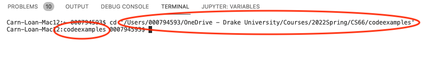

Now you should be able to run the program as normal and see the output.

## Group Activity Problem 4

For the program above, answer the following questions

1. What is the type of the `movies` variable?
2. How could you get it to print just the first record? Change the code and run it.
3. How could you get it to print the first 5 records? Change the code and run it.
4. Describe the structure of the data in `movies` - i.e., is it a list of lists? a list of dictionaries? Do the records contain other dictionaries in them? Do records contain lists? What are the types of the keys and values within each record?

## Group Activity Problem 5

Add this code to your file, and run it. Describe what it does.

```python
for m in movies:
    print(m["Title"])
```

## Group Activity Problem 6

Write the code that will print out the title of all movies that contain `"Star Wars"` in their name.

*Hint:* You can check if one string is a substring of another with code like

```python
"Star Wars" in "Star Wars: Episode VII - The Force Awakens (2015)"
```

## Group Activity Problem 7

Write the code that will print the names of all comedies (i.e., movies which contain "Comedy" as one of their items in the Genre list).

## Group Activity Problem 8

Write the code that will determine which comedy had the highest world sales (note that the file seems to be sorted by domestic sales, not world sales, so you will have to loop through all the records).

## Group Activity Problem 9

Write a function called `most_popular_in_genre` which takes in a list of movie records (in the same format as the `movies` variable above) and the name of a movie genre and returns the record of the movie from that genre with the highest world sales.

For example, if I call the function like this:

```python
print( most_popular_in_genre(movies,"Comedy") )
```

it should result in

```
{'Title': 'Frozen II (2019)', 'Summary': "Anna, Elsa, Kristoff, Olaf and Sven leave Arendelle to travel to an ancient, autumn-bound forest of an enchanted land. They set out to find the origin of Elsa's powers in order to save their kingdom.", 'Distributor': 'Walt Disney Studios Motion Pictures', 'Release Date': 'November 20, 2019', 'Domestic Sales': 477373578, 'International Sales': 972653355, 'World Sales': 1450026933, 'Genre': "['Adventure', 'Animation', 'Comedy', 'Family', 'Fantasy', 'Musical']", 'Runtime': '1 hr 43 min', 'MPAA Rating': 'PG'}
```

make sure not to refer to the global `movies` variable inside your function. This function should still work if I copied it into a new `.py` file and loaded it with a different data set that has the same form (for example, if I used an updated top 1000 movie data set in a few years).

Make sure to save your code for this exercise - we may continue working on it and turn it in for an assignment later.

# Announcements:

Tutoring Hours (Lauren)

You should be working on:

- [Assignment #1](https://analytics.drake.edu/~moore/CS66-F24/Assignment1.html), due tonight by 11:59pm
- [Assignment #2](https://analytics.drake.edu/~moore/CS66-F24/Assignment2.html), due Monday, 9/9, by 11:59 pm

> submit both to CodePost